# Lecture 6: Jensen and Joint Distibution

11/09/2019

## Pre-homework

## Turning Point 1

Let \(X\) be a random variable with \(\mathbb{E}(X)=3\).

**Question:** What is \(\mathbb{E}(3X - 6)\)?

**Answer:** 3

**Solution:**

\[\mathbb{E}(3X - 6) = \mathbb{E}(3X) - 6 = 3\mathbb{E}(X) - 6 = 3\cdot3 - 6 = 3\]

## Turning Point 2

**Question:** Is the function \(g(x) = 3x - 6\) convex and or concave?

**Answer:** Both!

**Solution:**

By Jensen's Inequality the function is concave if \[ \mathbb{E}[g(X)] \leq g(\mathbb{E}[X])\] and convex if \[ \mathbb{E}[g(X)] \geq g(\mathbb{E}[X]).\]

Given we have equality \(\mathbb{E}[g(X)] = g(\mathbb{E}[X])\) the function is both! Can also show this by considering first and second derivatives.

## Picture

To combine the measurements of both scientists, we need to account for the measurement error and transforming measurments to a common distribution (red dashed).

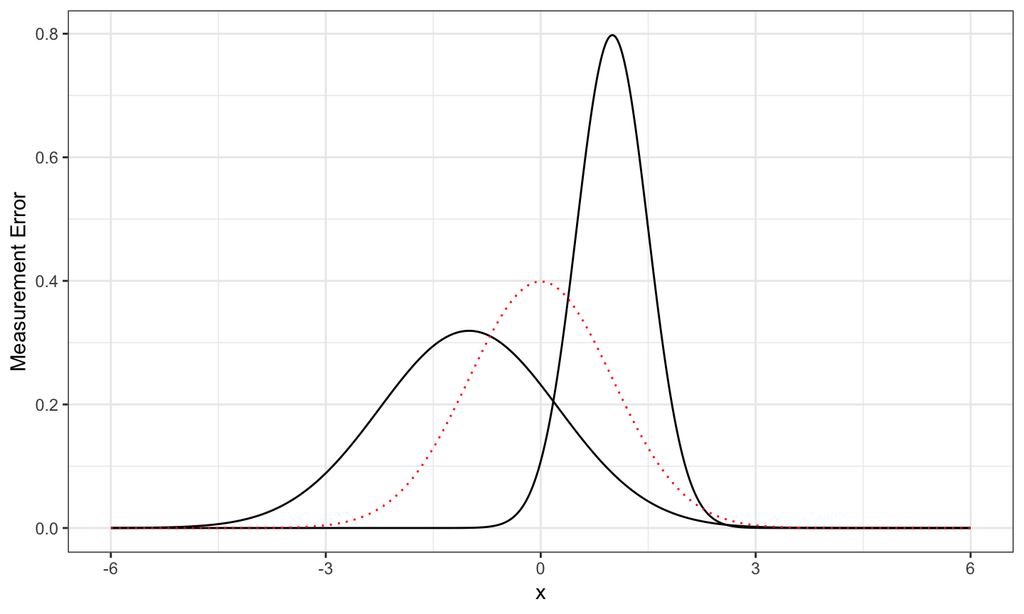

## Another example

Consider an IQ test where participants have a mean score of 100 and variance of 15. If we assume the scores are approximately normally distributed then \(X \sim N(100, 15)\)

To standardise the test scores, we us the transform: \[ Z = \dfrac{X - \mu}{\sigma} = \dfrac{X - 100}{\sqrt{15}}.\] IQ scores are not strictly measurable so standardisation is needed across tests.

## Turning Point 3a

**Question:** The joint distribution of RVs \(X\) and \(Y\) is always the product of the marginals

**Answer:** No

**Why:** If this statement was true then

\[\mathbb{P}(X \leq a, Y \leq b) = \mathbb{P}(X \leq a)\mathbb{P}(Y \leq b).\] and in the continuous case then we could separate the integrals

\[F_{XY}(a,b) = \int_{-\infty}^b\int_{-\infty}^a f(x,y) \text{d}x \text{d}y = \int_{-\infty}^a f(x) \text{d}x \int_{-\infty}^b f(y) \text{d}y = F_X(a)F_Y(b).\] However, this is clearly not possible for all functions \(f(x,y)\). Eg. If \(X \sim U(0, 1)\) and \(Y \sim U(0,x)\).

## Turning Point 3b

**Question:** If \(X \sim N(2,9)\) then \(\frac{X - 2}{3} \sim N(0,1)\)?

**Answer:** True

## Turning Point 4a

**Question:** Is \(f_x(x) = \int_{-\infty}^{\infty} f(x,y) \text{d}x\)?

**Answer:** No, the statements is false.

**Why:** To obtain the marginal density of \(x\) from the joint density we integrate over \(y\) not \(x\). It therefore should be \[f_x(x) = \int_{-\infty}^{\infty} f(x,y) \text{d}y.\]

## Turning Point 4b

**Question:** Is \(f_X(x) = \dfrac{\partial F_{XY}(x,y)}{\partial x}?\)

**Answer:** No, the statement is false.

**Why:** For distributions of a single random variable this is true \[f(x) = \dfrac{\text{d}F(x)}{\text{d}x},\] however for joint distributions such as \(F(x,y)\), \(y\) must also accounted for.